# Is Race Associated with Drug and Traffic Charges?

Eric Book

2019-05-15

### Cramer’s V

The top 20 Cramer’s V values measuring the association between traffic charges and drug charges have been tablulated. The Cramer’s V has values between 0 and 1 where 0 corresponds to no association and 1 with complete association.

A curious term, “enhancement,” appears in several charges. There is also a charge “SPEEDING 1MPH OVER” which may be a typo.

Ratios of Black inmates to White inmates are highest when traffic violations are paired with possession of marijuana. Ratios of White inmates to Black inmates are highest when open alcohol container violations are paired with drug paraphernalia violations.

Overall, there are measurable associations between traffic and drug charges, but the strength of the association is weak between individual charge category pairs.

| Drug Charge | Traffic Charge | Cramer's V | Race | N | Proportion |
| --- | --- | --- | --- | --- | --- |
| Drug paraphernalia - buy/possess 218a.500(2) | Failure of owner to maintain required insurance/security 1st offense | 0.08482 | Amer Indian/Alaska Native | 14 | 0.00 |
|  |  |  | Asian or Pacific Islander | 27 | 0.00 |
|  |  |  | Black-origins of Africa | 2,979 | 0.29 |
|  |  |  | Hispanic | 222 | 0.02 |
|  |  |  | White/Eurp/ N.Afr/Mid Eas | 6,921 | 0.68 |
|  | Operating on suspended or revoked operators license | 0.07993 | Amer Indian/Alaska Native | 12 | 0.00 |
|  |  |  | Asian or Pacific Islander | 22 | 0.00 |
|  |  |  | Black-origins of Africa | 2,941 | 0.30 |
|  |  |  | Hispanic | 89 | 0.01 |
|  |  |  | White/Eurp/ N.Afr/Mid Eas | 6,633 | 0.68 |
|  | No / expired registration plates | 0.07232 | Amer Indian/Alaska Native | 10 | 0.00 |
|  |  |  | Asian or Pacific Islander | 25 | 0.00 |
|  |  |  | Black-origins of Africa | 2,645 | 0.29 |
|  |  |  | Hispanic | 135 | 0.01 |
|  |  |  | White/Eurp/ N.Afr/Mid Eas | 6,401 | 0.69 |
| Poss of marijuana | Failure of owner to maintain required insurance/security 1st offense | 0.06552 | Amer Indian/Alaska Native | 10 | 0.00 |
|  |  |  | Asian or Pacific Islander | 20 | 0.00 |
|  |  |  | Black-origins of Africa | 3,351 | 0.47 |
|  |  |  | Hispanic | 220 | 0.03 |
|  |  |  | White/Eurp/ N.Afr/Mid Eas | 3,524 | 0.49 |
|  | Operating on suspended or revoked operators license | 0.06174 | Amer Indian/Alaska Native | 9 | 0.00 |
|  |  |  | Asian or Pacific Islander | 12 | 0.00 |
|  |  |  | Black-origins of Africa | 3,282 | 0.49 |
|  |  |  | Hispanic | 89 | 0.01 |
|  |  |  | White/Eurp/ N.Afr/Mid Eas | 3,258 | 0.49 |
|  | No / expired registration plates | 0.05585 | Amer Indian/Alaska Native | 6 | 0.00 |
|  |  |  | Asian or Pacific Islander | 18 | 0.00 |
|  |  |  | Black-origins of Africa | 3,018 | 0.49 |
|  |  |  | Hispanic | 132 | 0.02 |
|  |  |  | White/Eurp/ N.Afr/Mid Eas | 2,978 | 0.48 |

[output cut: 70 more lines]

### Odds Ratios

By looking at conditional odds ratios, we can ask a few different questions. If we know an inmate has a traffic charge, does being black instead of white increase the odds of also having a drug charge? Alternatively, if we know an inmate has a drug charge, does being black instead of white increase the odds of also having a traffic charge?

|  |  |  | Traffic |  |  |  |  |  |
| --- | --- | --- | --- | --- | --- | --- | --- | --- |
| Race | Drugs |  | No |  |  | Yes |  |  |
| Black-origins of Africa | Yes |  | 4078 |  |  | 1827 |  |  |
|  | No |  | 13818 |  |  | 3645 |  |  |
| White/Eurp/ N.Afr/Mid Eas | Yes |  | 6977 |  |  | 2359 |  |  |
|  | No |  | 19935 |  |  | 4819 |  |  |

From the plot below, we can see the frequencies are very similar across the board. So, we’re not likely to see large effect sizes.

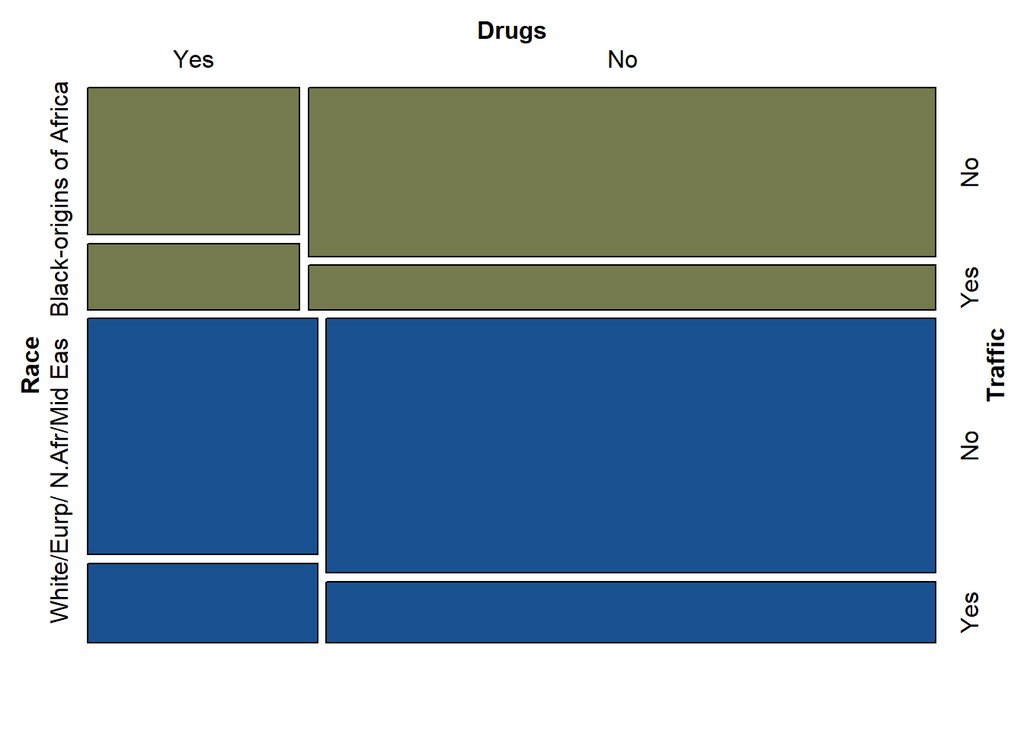

The odds ratio on the left says that given an inmate does *not* have traffic charge, a black inmate is on average 0.84 times *less* likely than a white inmate to have a drug charge

The odds ratio on the right says that given an inmate has a traffic charge, a black inmate is on average 1.02 times *more* likely than a white inmate to have a drug charge. Also, notice that this odds ratio’s confidence interval includes 1 which means we can’t say with certainty whether this effect actually exists.

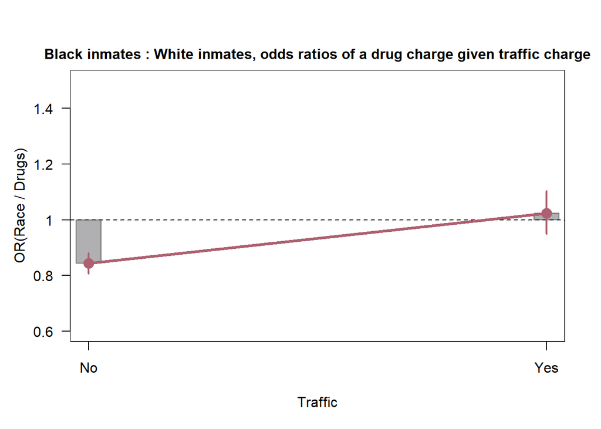

The odds ratio on the left says that given an inmate does *not* have drug charge, a black inmate is on average 1.09 times *more* likely than a white inmate to have a traffic charge.

The odds ratio on the right says that given an inmate has a drug charge, a black inmate is on average 1.33 times *more* likely than a white inmate to have a traffic charge.

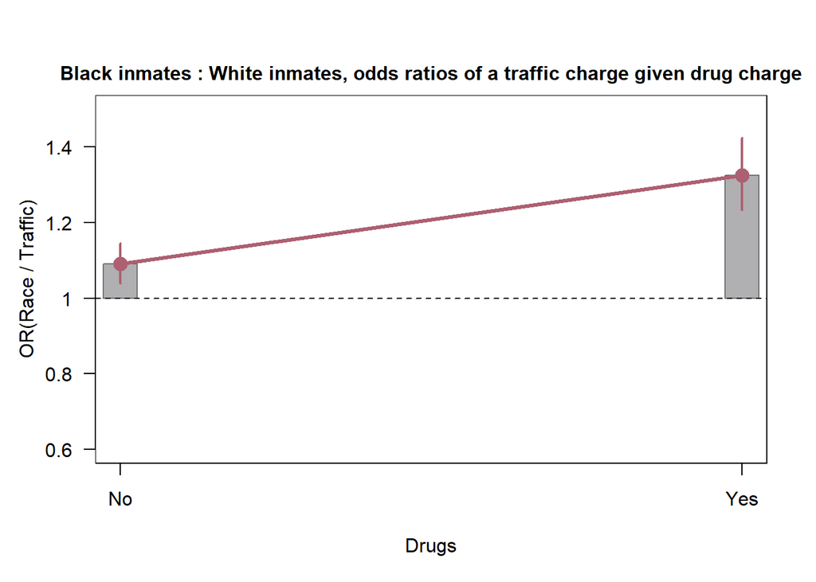